# Patient-Generated Health Data as a Predictor of Adverse Outcomes in Veterans

Study 1 - Pre-Event PGHD Surveillance Cohort

Nick Cardamone

May 27, 2026

Table S1. Missingness rates before imputation. ‘Weeks Missing’: % of person-week rows with a missing value. ‘Patients Missing’: % of patients with ≥1 missing week for that feature.

| Feature | Weeks Missing (%) | Patients Missing (%) |
| --- | --- | --- |
| Comorbidity flags |  |  |
| Acute renal failure, 2-year | 0.0 | 0.0 |
| Artificial openings, 2-year | 0.0 | 0.0 |
| Chronic pancreatitis, 2-year | 0.0 | 0.0 |
| Chronic skin/ulcer condition, 2-year | 0.0 | 0.0 |
| Congestive heart failure, 2-year | 0.0 | 0.0 |
| Substance use disorder, 2-year | 0.0 | 0.0 |
| Drug/alcohol-induced psychosis, 2-year | 0.0 | 0.0 |
| Lung/severe cancer, 2-year | 0.0 | 0.0 |
| Metastatic cancer, 2-year | 0.0 | 0.0 |
| Pregnancy/peripartum condition, 2-year | 0.0 | 0.0 |
| Cardiac arrhythmia, 2-year | 0.0 | 0.0 |
| Financial hardship, 2-year | 0.0 | 0.0 |
| Housing instability, 2-year | 0.0 | 0.0 |
| Nonspecific psychosocial condition, 2-year | 0.0 | 0.0 |
| Dialysis access, 2-year | 0.0 | 0.0 |
| Dialysis, 2-year | 0.0 | 0.0 |
| Multimorbidity Weighted Index (MWI) | 0.0 | 0.0 |
| Community care stay, any (2-year) | 0.0 | 0.0 |
| Community care stays, count (2-year) | 0.0 | 0.0 |
| Community care LOS, days (2-year) | 0.0 | 0.0 |
| Charlson Comorbidity Index (CCI) | 0.0 | 0.0 |
| Demographics |  |  |
| Age (years) | 0.3 | 0.2 |
| Days remaining in follow-up | 0.0 | 0.0 |
| Female (Male) | 0.0 | 0.0 |
| Unknown Sex (Male) | 0.0 | 0.0 |
| Black or African American (White) | 0.0 | 0.0 |
| American Indian or Alaska Native (White) | 0.0 | 0.0 |
| Asian (White) | 0.0 | 0.0 |

[output cut: 67 more lines]

# Methods

## Data

This study uses Patient-Generated Health Data (PGHD) from the VA Wearable Technology Program, in which Veterans voluntarily enrolled and shared wearable device data (Fitbit, Garmin, or Apple Health). Data were obtained from **January 01, 2022** through **May 14, 2026**. Daily step counts from Fitbit and Garmin devices were prioritized (using the higher value when both were present); Apple Health data served as an alternative when Fitbit/Garmin data were unavailable. A total of 7,402,730 patient-days had usable step data; Fitbit/Garmin data were available for 12.1% and Apple Health for the remainder. Daily step counts of zero were treated as missing, and outliers were removed using the 1.5×IQR method applied to raw device columns. Where step data were missing but exercise duration (minutes) was recorded, steps were imputed from a linear regression model fit on matched days (`steps ~ exercise_minutes`).

## Cohort Derivation (Figure 1)

The analytic cohort was drawn from Veterans who had enrolled in the VA Wearable Technology Program with PGHD data available from **January 01, 2022** through **May 14, 2026**. The enrollment criterion was a first PGHD upload between **January 01, 2022** and **April 14, 2026** (N = 14,046). The lower bound marks the program inception date; the upper bound preserves complete 30-day outcome ascertainment before the data extract end date. We retained all person-weeks with at least one day of step data (device-inactive weeks where no steps were uploaded are excluded implicitly by the rolling-window computation). We retained only patients who had at least one qualifying week in the baseline period (calendar weeks 1–6; days 1–42 after each patient’s actual first upload date) and at least one qualifying observation week (week 7 onward). Calendar weeks are indexed relative to each patient’s actual first upload date (week 1 = days 1–7, week 2 = days 8–14, etc.). Patients whose composite event (ED visit, inpatient admission, or death) occurred within the first 42 days after first upload (calendar weeks 1–6) were additionally excluded, as no event-free anchor period exists for them. Observation windows were then censored at the date of a first composite event or at 52 weeks from first upload, whichever came first. The final analytic cohort included **12,620 Veterans** contributing **401,446 person-weeks** of observation (weeks 7+).

## Step Feature Construction

At each observation week, a suite of step-derived features was computed from the 7-day, 14-day, and 21-day rolling windows anchored to the calendar week end-date. The primary current-activity features include the 7-day rolling average daily step count (`k_steps_7d_avg`, thousands), the rolling standard deviation (`k_steps_7d_sd`), the number of missing days in the window (`k_steps_7d_miss_days`), and the count of days with fewer than 1,000 steps (`low_activity_days_7d`). Two change metrics capture temporal trends: percent change from the average of the prior three 7-day windows (`k_steps_7d_avg_pctdiff`, winsorized at plus or minus 500%) and percent change from the 6-week baseline average (`k_steps_7d_pct_from_baseline`). Analogous 14-day and 21-day rolling averages and standard deviations provide longer-horizon smoothed signals. Two baseline summary features (mean steps and mean missing days across weeks 1-6) anchor the within-person normalization.

Taken together, the step features implement a Mundlak-style decomposition for a signal for high or lower activity relative to normal activity. `baseline_k_steps_avg`, the patient’s mean daily step count across the six baseline weeks, fixed at enrollment, serves as the between-person anchor, capturing stable individual-level activity capacity. `k_steps_7d_pct_from_baseline` and `k_steps_7d_avg_pctdiff` represent within-person deviations from that anchor, capturing departures from the patient’s own history over medium and short horizons respectively. Because the baseline is computed exclusively from pre-observation data (weeks 1–6), all deviation features are computable at any future prediction point without requiring knowledge of future step counts, a prerequisite for prospective deployment.

## Outcome Definition

The primary outcome was a composite of ED visit, inpatient admission, or death occurring within the prediction horizon ($h$ = 14 or 30 days) following a given observation week’s end date. The outcome was labeled positive ($Y = 1$) if any component occurred within 1 to $h$ days (`days_to_event` $\in [1, h]$), and negative ($Y = 0$) otherwise. For each prediction horizon $h$, observation weeks for non-event patients were excluded if fewer than $h$ days remained before the end of the patient’s observation window, as the outcome classification could not be confirmed over the full horizon. This ensures that 14-day models retain more person-weeks than 30-day models for the same patients.

## Statistical Analysis

We fit three feature sets: (1) step-derived features only (baseline + dynamic, *n* = 14 features); (2) static clinical features only (demographics, comorbidity flags, prior healthcare utilization, vitals, labs, and social history); and (3) the combined set. For each feature set and each prediction horizon (14-day and 30-day), we trained two algorithm types: penalized logistic regression (with elastic-net preprocessing) and gradient-boosted trees (XGBoost). Patients were randomly assigned to training (70%) and testing (30%) sets; all observation-weeks for a given patient remained in the same partition. To address class imbalance, logistic regression models were trained on patient-level 3:1 undersampled data; XGBoost models were trained on the full (non-undersampled) training data with `scale_pos_weight` set to the true negative-to-positive ratio, avoiding the probability compression that results from training and scoring on different class distributions.

To ensure accurate absolute risk estimates, predicted probabilities were calibrated using Platt scaling (logistic regression of observed outcomes on raw model log-odds). Calibration models were fit on a held-out 20% of training patients (patient-level split, preserving the original class distribution) and applied to the independent test set, ensuring no test-set information was used to fit the calibration model. All discrimination and calibration metrics were computed on the Platt-calibrated test-set probabilities. Model performance was evaluated using the Area Under the Receiver Operating Characteristic Curve (AUC-ROC), the Area Under the Precision-Recall Curve (PR-AUC), the post-calibration slope (target: 1.0), and the Brier Skill Score (BSS = 1 $-$ Brier/Brier$_{\text{null}}$, where Brier$_{\text{null}}$ = $\bar{p}(1-\bar{p})$). BSS accounts for the low baseline event rate (<3% per week): BSS = 0 indicates no improvement over a null model predicting the marginal event rate, and BSS = 1 indicates perfect probabilistic skill. The pre-calibration slope is additionally reported as a diagnostic of raw model output compression.

## Figure 1. Cohort Derivation

Figure 1. Cohort derivation flow table for Study 1: Person-weeks shown for observation period (weeks 7+) at steps 3–4; earlier rows show total qualifying weekly rows before baseline/observation split.

[output not shown]

## Cohort Derivation Diagnostics

The sections below inspect each CONSORT exclusion step to verify that exclusions are appropriate. These are computed by re-applying each filter in isolation from a snapshot of the weekly data (`dt_weekly_snapshot`) taken after rolling-feature construction but before any CONSORT filtering.

### Step 1: Distribution of first PGHD upload date by month

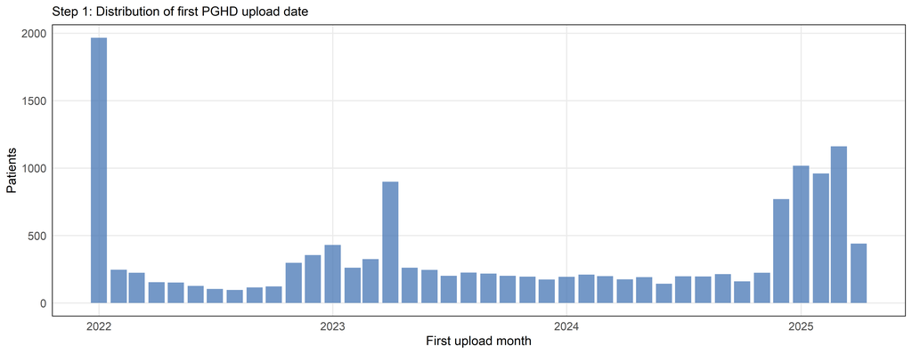

Distribution of first PGHD upload date by month for uploads through April 14, 2025.

### Step 2: Weekly Data Quality Threshold Sensitivity

Step 2 Sensitivity: Effect of varying the required minimum upload days per 7-day window.

| Quality criterion | Patients | Person-weeks | % patients retained | % weeks retained |
| --- | --- | --- | --- | --- |
| ≤0 missing (≥7 days present) | 13811 | 711870 | 98.3 | 57.4 |
| ≤1 missing (≥6 days present) | 13894 | 1000997 | 98.9 | 80.8 |
| ≤2 missing (≥5 days present) | 13934 | 1067890 | 99.2 | 86.2 |
| ≤3 missing (≥4 days present) | 13968 | 1104519 | 99.4 | 89.1 |
| ≤4 missing (≥3 days present) | 14002 | 1133892 | 99.7 | 91.5 |
| ≤5 missing (≥2 days present) | 14022 | 1161143 | 99.8 | 93.7 |
| ≤6 missing (≥1 days present) [current] | 14047 | 1239431 | 100.0 | 100.0 |

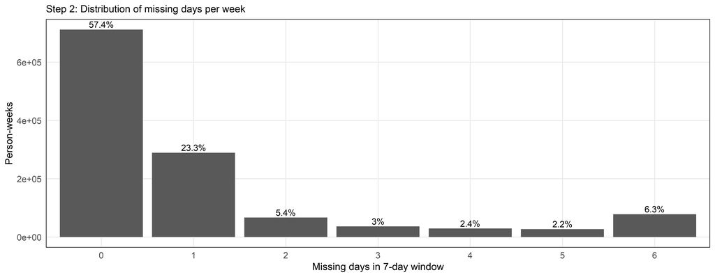

### Step 3: Minimum Baseline Length Sensitivity

Step 3 Sensitivity: Effect of varying the minimum required baseline length.

| Baseline length | Patients retained | Observation person-weeks | % of post-step2 patients |
| --- | --- | --- | --- |
| 2 weeks | 13885 | 1082486 | 99.4 |
| 4 weeks | 13829 | 1060997 | 99.0 |
| 6 weeks [current] | 13763 | 1039580 | 98.5 |
| 8 weeks | 13705 | 1018174 | 98.1 |
| 10 weeks | 13655 | 996768 | 97.8 |
| 12 weeks | 13593 | 975421 | 97.3 |

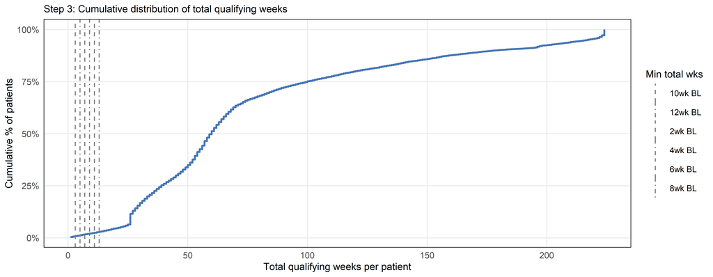

Cumulative distribution of total qualifying weeks per patient (after Steps 1–2). Patients to the left of each vertical line would be excluded by the corresponding minimum baseline requirement.

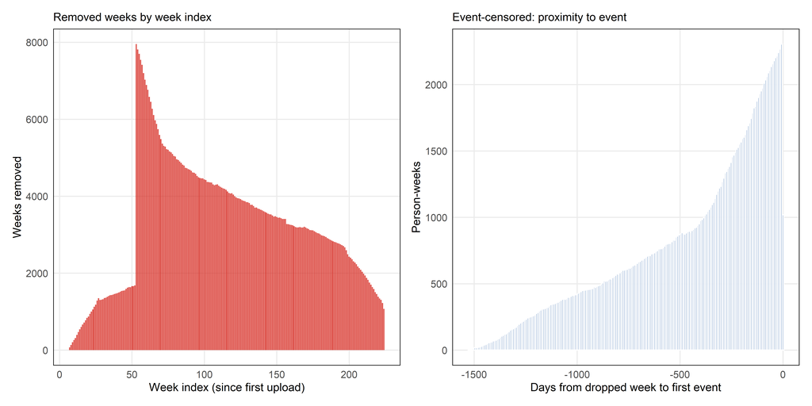

Left: Distribution of weekly_interval_index for removed person-weeks (weeks dropped by censoring). Right: Distribution of days_to_event at the time of removal for event-censored rows (i.e., how far in the future was the event relative to the dropped week?).

# Results: Study 1 - Pre-Event PGHD Surveillance Cohort

## Table 1. Sample Characteristics

| **Characteristic** | **Overall** N = 12,620<sup>1</sup> | **Death** N = 14<sup>1</sup> | **Inpatient** N = 961<sup>1</sup> | **ED Visit** N = 1,582<sup>1</sup> | **No Event** N = 10,063<sup>1</sup> | **p-value**<sup>2</sup> |
| --- | --- | --- | --- | --- | --- | --- |
| Baseline avg. steps (steps/day) | 5,563.9 (2,908.9); 5,280.8 (3,378.6, 7,460.0) | 3,057.7 (2,062.7); 2,158.5 (1,755.1, 4,603.5) | 4,772.7 (2,759.8); 4,522.7 (2,639.4, 6,389.2) | 5,274.4 (2,842.1); 4,938.7 (3,181.1, 7,016.3) | 5,688.5 (2,917.8); 5,426.2 (3,498.8, 7,619.0) | <0.001 |
| Baseline avg. missing days/week | 1.4 (2.0); 0.3 (0.2, 1.8) | 0.3 (0.3); 0.2 (0.2, 0.3) | 1.0 (1.6); 0.3 (0.2, 0.7) | 1.3 (1.8); 0.3 (0.2, 1.3) | 1.5 (2.0); 0.3 (0.2, 2.0) | <0.001 |
| Observation avg. steps (steps/day) | 5,597.3 (2,700.6); 5,399.9 (3,570.0, 7,396.0) | 3,632.5 (3,271.3); 2,395.1 (1,529.3, 4,940.8) | 4,761.9 (2,698.3); 4,546.7 (2,695.8, 6,379.7) | 5,329.8 (2,729.6); 5,057.5 (3,296.1, 7,027.1) | 5,721.9 (2,677.4); 5,542.7 (3,735.3, 7,544.4) | <0.001 |
| Observation avg. missing days/week | 1.4 (1.8); 0.6 (0.3, 1.5) | 0.9 (0.7); 0.6 (0.3, 0.8) | 1.0 (1.5); 0.4 (0.2, 0.9) | 1.2 (1.7); 0.4 (0.3, 1.3) | 1.5 (1.8); 0.6 (0.3, 1.7) | <0.001 |
| Total observation weeks (post-baseline) | 31.8 (15.1); 37.0 (21.0, 46.0) | 28.8 (11.5); 29.5 (22.0, 34.0) | 19.7 (13.4); 18.0 (9.0, 29.0) | 18.1 (12.8); 16.0 (7.0, 26.0) | 35.1 (13.7); 45.0 (24.0, 46.0) | <0.001 |
| Observation weeks with data coverage (%) | 90.3 (22.6); 100.0 (100.0, 100.0) | 100.0 (0.0); 100.0 (100.0, 100.0) | 94.7 (16.9); 100.0 (100.0, 100.0) | 93.7 (18.5); 100.0 (100.0, 100.0) | 89.3 (23.6); 100.0 (97.8, 100.0) | <0.001 |
| Age (years) | 52.0 (13.3); 52.0 (42.0, 61.0) | 62.0 (11.8); 64.5 (52.0, 73.0) | 54.3 (13.9); 54.0 (44.0, 65.0) | 52.6 (13.2); 53.0 (42.0, 62.0) | 51.7 (13.2); 51.0 (42.0, 61.0) | <0.001 |
| Unknown | 30 | 0 | 0 | 0 | 30 |  |
| Sex |  |  |  |  |  |  |
| Female (ref) | 2,501 (20%) | 0 (0%) | 209 (22%) | 360 (23%) | 1,932 (19%) |  |
| Male | 10,089 (80%) | 14 (100%) | 752 (78%) | 1,222 (77%) | 8,101 (81%) |  |
| Unknown | 30 (0.2%) | 0 (0%) | 0 (0%) | 0 (0%) | 30 (0.3%) |  |
| Race |  |  |  |  |  |  |
| White (ref) | 9,091 (72%) | 8 (57%) | 729 (76%) | 1,089 (69%) | 7,265 (72%) |  |
| American Indian or Alaska Native | 108 (0.9%) | 2 (14%) | 10 (1.0%) | 13 (0.8%) | 83 (0.8%) |  |
| Asian | 174 (1.4%) | 0 (0%) | 9 (0.9%) | 14 (0.9%) | 151 (1.5%) |  |
| Black or African American | 2,021 (16%) | 1 (7.1%) | 136 (14%) | 361 (23%) | 1,523 (15%) |  |
| Native Hawaiian or Other Pacific Islander | 106 (0.8%) | 0 (0%) | 7 (0.7%) | 11 (0.7%) | 88 (0.9%) |  |
| Unknown | 1,120 (8.9%) | 3 (21%) | 70 (7.3%) | 94 (5.9%) | 953 (9.5%) |  |
| Ethnicity |  |  |  |  |  |  |
| Not Hispanic or Latino (ref) | 10,768 (85%) | 11 (79%) | 839 (87%) | 1,360 (86%) | 8,558 (85%) |  |
| Hispanic or Latino | 1,246 (9.9%) | 1 (7.1%) | 85 (8.8%) | 183 (12%) | 977 (9.7%) |  |
| Unknown | 606 (4.8%) | 2 (14%) | 37 (3.9%) | 39 (2.5%) | 528 (5.2%) |  |
| Marital status |  |  |  |  |  |  |
| Married (ref) | 7,524 (60%) | 9 (64%) | 545 (57%) | 849 (54%) | 6,121 (61%) |  |
| Divorced | 2,140 (17%) | 2 (14%) | 200 (21%) | 315 (20%) | 1,623 (16%) |  |
| Never Married | 2,228 (18%) | 2 (14%) | 154 (16%) | 310 (20%) | 1,762 (18%) |  |
| Separated | 344 (2.7%) | 0 (0%) | 29 (3.0%) | 68 (4.3%) | 247 (2.5%) |  |
| Widowed | 136 (1.1%) | 0 (0%) | 20 (2.1%) | 25 (1.6%) | 91 (0.9%) |  |
| Unknown | 248 (2.0%) | 1 (7.1%) | 13 (1.4%) | 15 (0.9%) | 219 (2.2%) |  |

[output cut: 76 more lines]

<sup>1</sup> Mean (SD); Median (Q1, Q3); n (%)  
<sup>2</sup> Kruskal-Wallis rank sum test; NA; Fisher’s exact test

## Figure 2. Time to First Composite Event

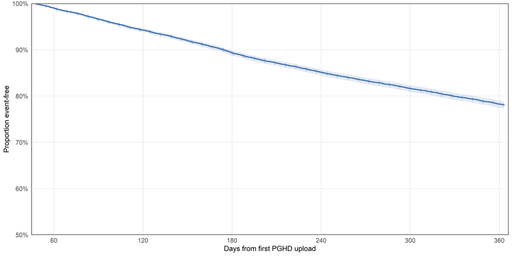

Figure 2. Kaplan-Meier survival curve for time from first PGHD upload to first composite event (ED visit, inpatient admission, or death) among the analytic cohort. The y-axis shows the proportion of patients remaining event-free. Tick marks indicate censored observations. Shaded band represents the 95% pointwise confidence interval.

## Figure 3. Step Trajectories Before First Event

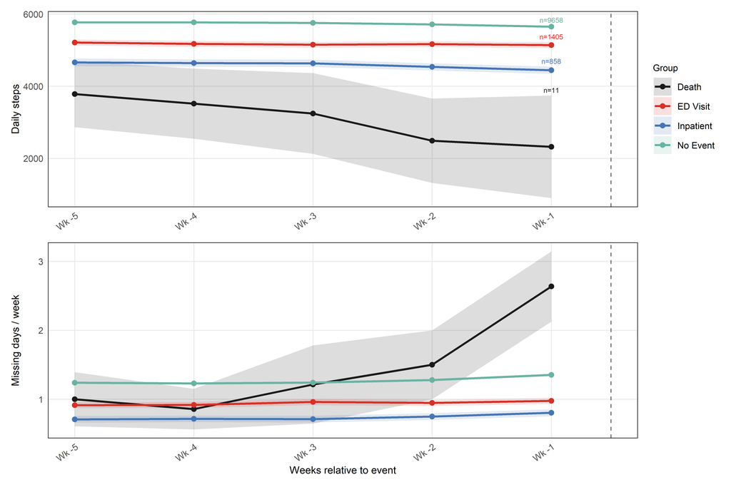

Figure 3. Mean 7-day rolling average daily step count (+/- 1 SE) and mean missing days per week (+/- 1 SE) in the 5 weeks before first composite event (ED Visit, Inpatient admission, Death) or in a randomly selected reference 5-week window for the No Event group. Dashed vertical line marks the reference week (week −1 = most recent week; week −5 = earliest). Bands represent +/- 1 SE across patients. n = number of patients contributing to each group at week −1.

## Table 2. Predictive Model Performance

Table 2. Model performance on the 30% patient-level hold-out test set.

| Feature set | 14-day horizon AUC | 14-day horizon PR-AUC | 14-day horizon BSS | 14-day horizon Cal. slope | 14-day horizon Events | 30-day horizon AUC | 30-day horizon PR-AUC | 30-day horizon BSS | 30-day horizon Cal. slope | 30-day horizon Test N | 30-day horizon Events |
| --- | --- | --- | --- | --- | --- | --- | --- | --- | --- | --- | --- |
| Null model |  |  |  |  |  |  |  |  |  |  |  |
| Null model (event rate) | 0.5000 | 0.0112 | 0.0000 | – | 1,346 | 0.5000 | 0.0230 | 0.0000 | – | 120,561 | 2,770 |
| Logistic regression |  |  |  |  |  |  |  |  |  |  |  |
| Static only | 0.7108 | 0.0272 | −0.0017 | 1.0026 | 1,346 | 0.7044 | 0.0535 | 0.0046 | 0.8513 | 120,561 | 2,770 |
| Steps + static | 0.7081 | 0.0275 | −0.0130 | 0.7754 | 1,346 | 0.7092 | 0.0550 | −0.0019 | 0.8369 | 120,561 | 2,770 |
| Steps only | 0.5703 | 0.0140 | 0.0006 | 1.2325 | 1,346 | 0.5723 | 0.0291 | 0.0011 | 2.0263 | 120,561 | 2,770 |
| XGBoost |  |  |  |  |  |  |  |  |  |  |  |
| Static only | 0.7082 | 0.0286 | 0.0079 | 1.0570 | 1,346 | 0.7143 | 0.0572 | 0.0164 | 0.9438 | 120,561 | 2,770 |
| Steps + static | 0.7108 | 0.0280 | 0.0082 | 1.1454 | 1,346 | 0.7111 | 0.0593 | 0.0165 | 0.9156 | 120,561 | 2,770 |
| Steps only | 0.5654 | 0.0136 | 0.0005 | 1.4892 | 1,346 | 0.5638 | 0.0291 | 0.0009 | 1.8199 | 120,561 | 2,770 |

**Note.** AUC = area under ROC curve; PR-AUC = precision-recall AUC; BSS = Brier Skill Score; BSS = 0 indicates no improvement over the null model (event rate), BSS = 1 is perfect; Cal. slope = post-calibration slope on test set (target: 1.0); Platt scaling fit on held-out 20% of training patients (patient-level), applied to test set for all metrics.

### Sensitivity Analyses

Table S1. Sensitivity Analysis B: Test-set performance stratified by weekly data quality at the 30-day horizon. ‘Clean’: 0–3 missing days per week (≥4 days with step data). ‘Sparse’: 4–6 missing days per week (1–3 days with step data). No model refit - stratified evaluation within the primary model. Comparable performance across strata indicates the model captures pre-event device-dropout signal present in sparse weeks.

| Feature set | Stratum | Person-weeks | Events | AUC | PR-AUC | BSS |
| --- | --- | --- | --- | --- | --- | --- |
| Logistic regression |  |  |  |  |  |  |
| Static only | clean (miss ≤3) | 107,013 | 2,550 | 0.7037 | 0.0554 | 0.0053 |
| Static only | sparse (miss 4–6) | 13,548 | 220 | 0.6946 | 0.0348 | −0.0065 |
| Steps + static | clean (miss ≤3) | 107,013 | 2,550 | 0.7083 | 0.0565 | −0.0024 |
| Steps + static | sparse (miss 4–6) | 13,548 | 220 | 0.7121 | 0.0370 | 0.0002 |
| Steps only | clean (miss ≤3) | 107,013 | 2,550 | 0.5638 | 0.0295 | 0.0008 |
| Steps only | sparse (miss 4–6) | 13,548 | 220 | 0.6259 | 0.0236 | 0.0013 |
| XGBoost |  |  |  |  |  |  |
| Static only | clean (miss ≤3) | 107,013 | 2,550 | 0.7114 | 0.0586 | 0.0165 |
| Static only | sparse (miss 4–6) | 13,548 | 220 | 0.7291 | 0.0420 | 0.0118 |
| Steps + static | clean (miss ≤3) | 107,013 | 2,550 | 0.7068 | 0.0605 | 0.0165 |
| Steps + static | sparse (miss 4–6) | 13,548 | 220 | 0.7394 | 0.0450 | 0.0131 |
| Steps only | clean (miss ≤3) | 107,013 | 2,550 | 0.5517 | 0.0292 | 0.0007 |
| Steps only | sparse (miss 4–6) | 13,548 | 220 | 0.6152 | 0.0276 | 0.0007 |

## Table 3. Model Calibration: 14-Day and 30-Day Horizons

Table 3. Calibration table for 14-day and 30-day horizon models. Predicted probabilities are grouped into decile-based bins; observed event rates are compared to mean predicted probabilities within each bin. Well-calibrated models show observed rates close to mean predicted values.

| Predicted prob. bin | N | Events (n) | Mean predicted | Observed rate |
| --- | --- | --- | --- | --- |
| 14-day - Static only - Logistic |  |  |  |  |
| [0.00596,0.00688] | 12,059 | 21 | 0.007 | 0.002 |
| (0.00688,0.00732] | 12,064 | 54 | 0.007 | 0.004 |
| (0.00732,0.00756] | 12,049 | 64 | 0.007 | 0.005 |
| (0.00756,0.00778] | 12,054 | 80 | 0.008 | 0.007 |
| (0.00778,0.00802] | 12,056 | 72 | 0.008 | 0.006 |
| (0.00802,0.00835] | 12,056 | 117 | 0.008 | 0.010 |
| (0.00835,0.00889] | 12,060 | 115 | 0.009 | 0.010 |
| (0.00889,0.0101] | 12,059 | 146 | 0.009 | 0.012 |
| (0.0101,0.0156] | 12,054 | 268 | 0.012 | 0.022 |
| (0.0156,0.877] | 12,050 | 409 | 0.027 | 0.034 |
| 14-day - Static only - Xgboost |  |  |  |  |
| [0.00316,0.00399] | 20,639 | 68 | 0.004 | 0.003 |
| (0.00399,0.00412] | 4,035 | 14 | 0.004 | 0.003 |
| (0.00412,0.00543] | 12,694 | 46 | 0.005 | 0.004 |
| (0.00543,0.00734] | 10,901 | 64 | 0.006 | 0.006 |
| (0.00734,0.00941] | 17,802 | 164 | 0.009 | 0.009 |
| (0.00941,0.0103] | 7,815 | 84 | 0.010 | 0.011 |
| (0.0103,0.0117] | 10,551 | 85 | 0.011 | 0.008 |
| (0.0117,0.0142] | 12,319 | 145 | 0.013 | 0.012 |
| (0.0142,0.0276] | 11,762 | 285 | 0.021 | 0.024 |
| (0.0276,0.0515] | 12,043 | 391 | 0.034 | 0.032 |
| 14-day - Steps + static - Logistic |  |  |  |  |
| [0.00536,0.00654] | 12,057 | 34 | 0.006 | 0.003 |
| (0.00654,0.00701] | 12,056 | 49 | 0.007 | 0.004 |
| (0.00701,0.00741] | 12,056 | 70 | 0.007 | 0.006 |
| (0.00741,0.00776] | 12,056 | 58 | 0.008 | 0.005 |
| (0.00776,0.00813] | 12,056 | 72 | 0.008 | 0.006 |
| (0.00813,0.00861] | 12,056 | 117 | 0.008 | 0.010 |
| (0.00861,0.00936] | 12,056 | 142 | 0.009 | 0.012 |

[output cut: 102 more lines]

## Figure 4. ROC Curves at 30-Day Horizon

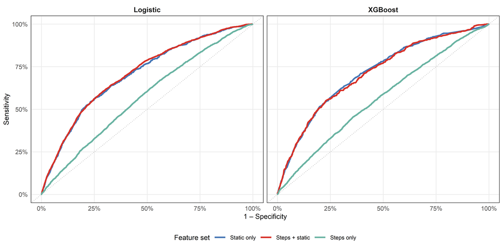

## Figure 5. XGBoost Feature Importance: Steps + Static Model

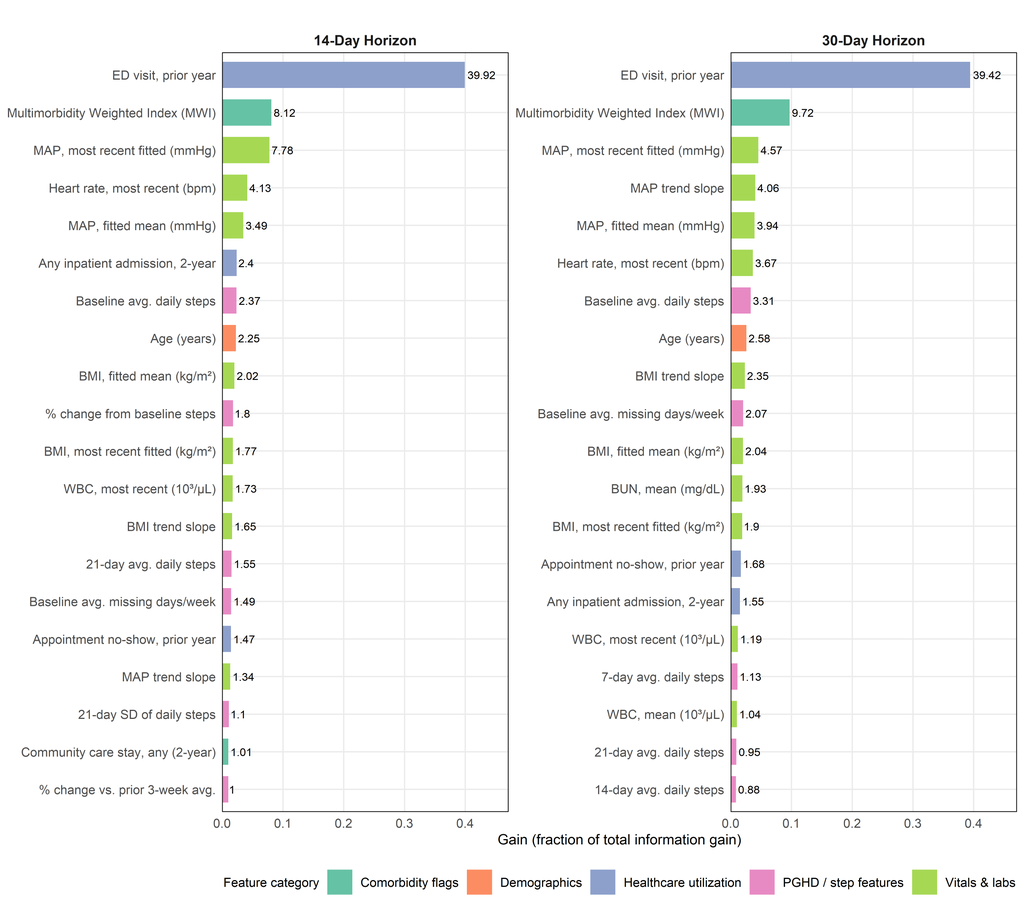

Figure 5. Top 20 XGBoost feature importances (Gain): Steps + Static, 14-Day and 30-Day Horizons. Bars filled by feature category (colorblind-friendly Set2 palette). Gain = fractional contribution to total information gain across all trees. Labels show Gain x 100.

## Figure 6. Logistic Regression Coefficients: Steps + Static Model

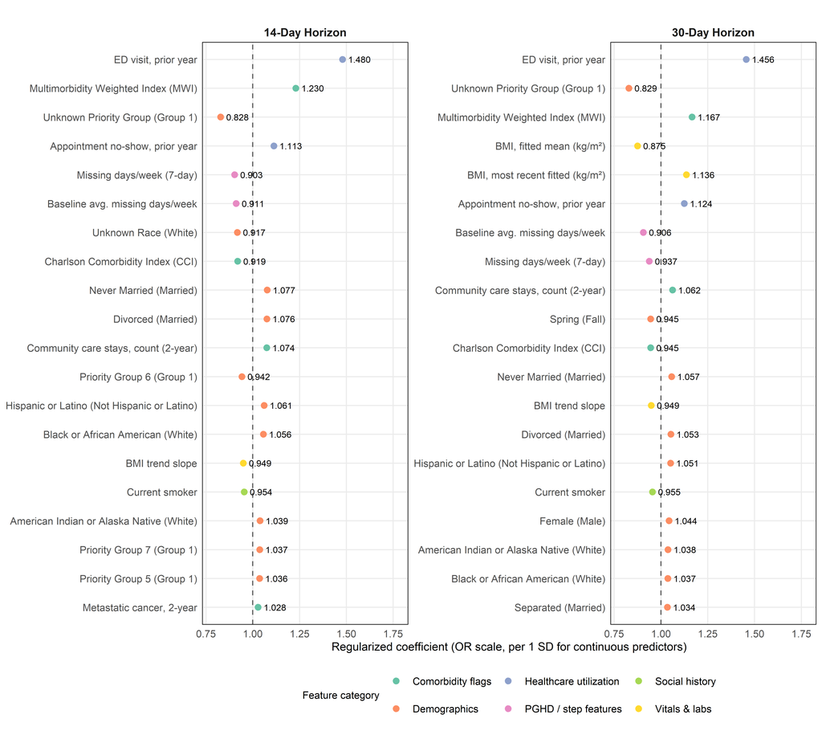

Figure 6. Top 20 elastic net–regularized logistic regression coefficients (OR scale, per 1 SD for continuous predictors): Steps + Static, 14-Day and 30-Day Horizons. Colored by feature category (Set2 palette). These are penalized estimates and should be interpreted as directional associations reflecting relative feature importance within the model, not formal hypothesis tests.

*Note: Coefficients are elastic net–penalized estimates (glmnet, Steps + Static model). Penalization shrinks estimates toward zero and the plot carries no inferential standard errors or significance thresholds; values reflect the direction and relative magnitude of each feature’s contribution within the regularized model. A full coefficient table is saved to `logistic_coefficients_14d_30d.xlsx`.*

*Analysis completed: 2026-05-27 15:45*  
*Seed: 2026 | R version: R version 4.5.0 (2025-04-11 ucrt)*